# Cálculo com Python

Nesta segunda parte do minicurso vamos estudar como calcular limites de funções de uma variável usando a biblioteca [Python](https://www.python.org/) de matemática simbólica [SymPy](http://www.sympy.org).

## 2 - Limites

Nesta segunda parte do minicurso vamos estudar a computar em [Python](https://www.python.org/):

- **limites no ponto**
- **limites laterais**
- **limites no infinito**

Começamos importando a biblioteca [SymPy](http://www.sympy.org/):

```python
from sympy import *
init_printing()
# define x e y como variáveis simbólicas
var('x y')
```

$$\left ( x, \quad y\right )$$

Agora, para fixarmos as ideias, vamos continuar nosso estudo sobre a

$f(x) = (x^3 - 3x + 2)e^{-x/4} - 1$.

Para, tanto vamos definí-la novamente:

```python
f = Lambda(x, (x**3 - 3*x + 2)*exp(-x/4)-1)
f
```

$$\left( x \mapsto \left(x^{3} - 3 x + 2\right) e^{- \frac{x}{4}} - 1 \right)$$

Estamos prontos para iniciar nosso estudo sobre limites com [Python](https://www.python.org/).

### Limites no ponto

Podemos usar o [SymPy](https://www.sympy.org) para calcular o limite de uma função $f(x)$ quando $x$ tende a um ponto $a$, i.e.

$\displaystyle \lim_{x\to a} f(x)$.

Como exemplo, vamos calcular

$\displaystyle \lim_{x\to 1} f(x)$

para a função definida acima. Para tanto, podemos usar a função [`limit`](https://docs.sympy.org/latest/modules/series/series.html?highlight=limit#sympy.series.limits.limit):

```python
limit(f(x),x,1)
```

$$-1$$

Note que este é o valor esperado, pois $f(x)$ é uma função contínua e já haviamos visto que $f(1) = -1$ (verifique!).

#### Exercício

Considere a seguinte a função $g(x) = 2 - \sqrt{x^2 - 1}$. Calcule

$\displaystyle \lim_{x\to -1} g(x)$.

```python
#digite sua resposta aqui!
```

### Limites Lateriais

Por padrão, o comando [`limit`](https://docs.sympy.org/latest/modules/series/series.html?highlight=limit#sympy.series.limits.limit) computa o limite lateral pela direita. Por exemplo:

$\displaystyle \lim_{x\to 0} \frac{|x|}{x} = \not\exists$

mas,

$\displaystyle \lim_{x\to 0^+} \frac{|x|}{x} = 1$

e, no [SymPy](https://www.sympy.org/):

```python
limit(abs(x)/x,x,0)
```

$$1$$

Para calcularmos o limite pela esquerda, i.e.:

$\displaystyle \lim_{x\to 0^-} \frac{|x|}{x} = -1$

digitamos:

```python
limit(abs(x)/x,x,0,'-')
```

$$-1$$

#### Exercício:

Compute

$\displaystyle \lim_{x\to 0} \frac{1}{x}$.

Este limite existe? Caso o limite não exista, calcule os limites laterais correspondentes.

```python
#digite sua resposta aqui!
```

### Limites no infinito

Também podemos usar o comando [`limit`](https://docs.sympy.org/latest/modules/series/series.html?highlight=limit#sympy.series.limits.limit) para computar limites no infinito. Por exemplo, vejamos o limite de:

$\displaystyle \lim_{x\to \infty} f(x) = -1$

```python
limit(f(x), x, oo)
```

$$-1$$

Agora, vamos computar:

$\displaystyle \lim_{x\to -\infty} f(x)$

(você saberia dizer quanto vale este limite?)

```python
limit(f(x), x, -oo)
```

$$-\infty$$

Opa! O

$\displaystyle \lim_{x\to\infty} f(x) = -1$

nos indica que $f(x)$, de fato, tem pelo menos mais um zero à direita de $x \approx 1,643$ (veja a discussão ao final da parte 1-funções deste minicurso). Ao plotarmos o gráfico de $f(x)$ para valor maiores de $x$, obtemos

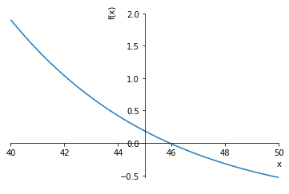

```
<sympy.plotting.plot.Plot at 0x7f8dfc7fc208>
```

```python
%matplotlib inline
plot(f(x), (x, 40, 50))
```

vemos que $f(x)$ tem um zero próximo de $x = 46$. Confirmamos isso calculando:

```python
nsolve(f(x), x, 46)
```

$$45.9162038717966$$

#### Exercício:

Encontre:

(a) $\displaystyle \lim_{x\to \infty} \left(1 + \frac{1}{x}\right)^x$

(b) $\displaystyle \lim_{x\to -\infty} \left(1 + \frac{1}{2x}\right)^{x}$

```python
# digite sua solução aqui!
```

#### Exercício:

Existe o $\displaystyle \lim_{x\to \infty} \text{sen}~x$?

```python
#Digite sua resolução aqui.
```

## Referências

- [1] Python Software Fundation (US): [www.python.org](https://www.python.org/)
- [2] Sympy - Python Library for Symbolic Mathematics: [www.sympy.org](http://www.sympy.org/)

## Ligações relacionadas

- [1] Sympy Gamma: [www.sympygamma.org](http://www.sympygamma.com/)
- [2] Sympy Live: [live.sympy.org](http://live.sympy.org/)
- [3] Jupyter: https://jupyter.org/
- [4] Binder: https://mybinder.org/

#### Próxima parte: 3 - Derivadas.

Criado em Out/2015 Última modificação: Out/2019

O texto acima está sob Licença [Creative Commons Atribuição-CompartilhaIgual 4.0 Internacional](http://creativecommons.org/licenses/by-sa/4.0/deed.pt_BR). Contato

**Erros? Sugestões?**

Clique aqui para informar erros ou deixar sujestões!